# Fatal Crashes in the US

Amit Min, Zain Shahzad, John Lickteig, Lauren McCormick

4/25/2020

# Introduction

Driving under the influence is a major problem in our country. Almost 30 people die every day in the United States in crashes that involve a driver impaired by alcohol. There are over 100 million self-reported instances of alcohol-impaired driving every year, as more than a million drivers are arrested for driving under the influence of alcohol or other drugs. This is a problem that is only worsening as the years go by. Even with preventative actions taken by the government and national awareness of the issue, there seems to be little to no effect on yearly reported numbers of fatalities involving impaired drivers. Our group explored the national fatal car crash dataset from 2015 to learn more about why these accidents keep happening, and how to prevent them. In researching this topic in depth, we narrowed our interests down to two questions:

Can we predict if a drunk driver was present in a fatal crash?

Are there population-level factors that can be used to predict the per capita rate of fatal drunk driving crashes in a given area?

For data regarding question #1, our group wanted to know if there is any way to predict if a drunk driver was present in a crash using different conditions as predictors. Knowing if there is a strong relationship between fatalities by drunk drivers and different surrounding conditions can help us understand patterns that are associated with our topic at hand. This can spark new ideas about creating new preventative measures for certain people and places that may be a threat to drivers on the road. Our second question looked at the characteristics associated with rates of drunk driving per capita in counties across the United States. Understanding the association between population-level characteristics and drunk driving crashes could allow us to identify potential drunk driving “hotspots” and subsequently design and enact targeted interventions in those areas. Through exploring our two questions, we may be able to create awareness about the patterns of drunk driving in the United States. More importantly, we can modify the lens through which drunk driving is viewed to create more progressive conversations to ultimately keep the citizens safe.

# Data

This data was compiled by the National Highway Traffic Safety Administration and hosted by Kaggle. The datatset was made in an effort to draw ideas and suggest solutions in order to approach this problem in an objective way. The dataset contains data on every fatal crash that occurs within the United States and invlves a motor vehicle. Totalling 70 columnns of variables, this dataset had many possible avenues for analysis. The data for the year 2015 contains 32,538 unique observations in which fatal accidents occurred. The data for the year 2016 contains 34,722 observations. Each observation contains a response for each of the 70 variables that can be used to discern the details of the crash.

Because the data is listed by individual observations, our analysis often consists of counting the occurances of a specific variable and comparing multiple variables in order to draw a conclusion. The following table shows the example of what our “cleaned” data may look like. We count the number of accidents per capita, and the drunks accidents per capita. We can then see if there is a correlation between the two (which it appears there is!).

|  | state | Amount | Population | AccidentsPerCapita | drunkCases | DrunksPerCapita |
| --- | --- | --- | --- | --- | --- | --- |
| 51 | Wyoming | 129 | 563626 | 0.0002288752 | 53 | 0.0000940000 |
| 27 | Montana | 204 | 989415 | 0.0002061824 | 88 | 0.0000889000 |
| 25 | Mississippi | 604 | 2967297 | 0.0002035523 | 126 | 0.0000425000 |
| 41 | South Carolina | 911 | 4625364 | 0.0001969575 | 296 | 0.0000640000 |
| 4 | Arkansas | 491 | 2915918 | 0.0001683861 | 135 | 0.0000463000 |
| 35 | North Dakota | 111 | 672591 | 0.0001650334 | 50 | 0.0000743000 |
| 1 | Alabama | 784 | 4779736 | 0.0001640258 | 216 | 0.0000452000 |
| 18 | Kentucky | 694 | 4339367 | 0.0001599312 | 194 | 0.0000447000 |
| 37 | Oklahoma | 590 | 3751351 | 0.0001572767 | 162 | 0.0000432000 |
| 19 | Louisiana | 698 | 4533372 | 0.0001539693 | 251 | 0.0000554000 |
| 10 | Florida | 2699 | 18801310 | 0.0001435538 | 626 | 0.0000333000 |
| 42 | South Dakota | 116 | 814180 | 0.0001424746 | 41 | 0.0000504000 |
| 8 | Delaware | 127 | 897934 | 0.0001414358 | 37 | 0.0000412000 |
| 43 | Tennessee | 888 | 6346105 | 0.0001399283 | 269 | 0.0000424000 |
| 11 | Georgia | 1329 | 9687653 | 0.0001371849 | 296 | 0.0000306000 |

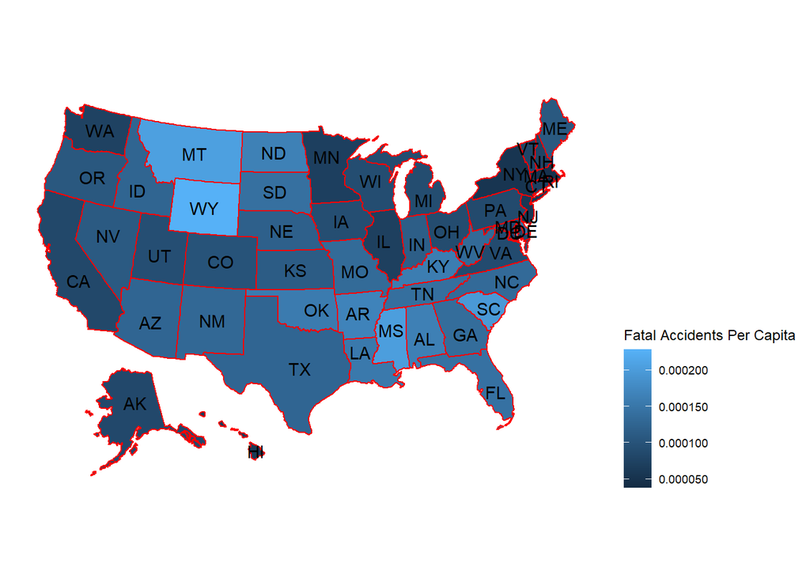

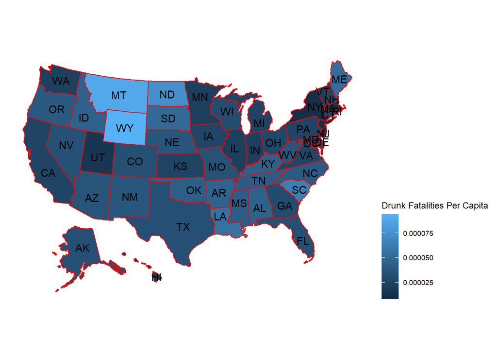

We first asked if it was possible to predict if a drunk driver was involved in a crash. We used “Type” which contains the collision type such as front-to-front or front-to-rear. “Probability” contains a binary yes or no response for if the driver was drunk. “Hour” contains an hour of crash time from 0-24, with 0 being the start of a new day. “Land” indicates the type of land that the crash occurred on such as rural or urban.

In order to answer our second question regarding potential population-level predictors of fatal drunk driving crashes, we first had to aggregate our data by location. We chose to conduct this analysis at the county level because doing so gave us a substantial number of data points and allowed us to easily link our dataset with census information. Our data also contained information about the state and city in which a crash occurred, but using state-aggregated data would have only given us 50 observations to work with and using city-aggregated data would have made it more difficult to link up with population information from the census. Ultimately, we ended up with 2870 observations of five variables after aggregation. The five variables included in this dataset were state_name, state_abbrev, county, total_crashes, and total_drunk_driver where total_crashes represents the sum of all fatal crashes in a given county and total_drunk_driver represents the sum of fatal crashes involving a drunk driver. For this portion of our analysis we used combined data from 2015 and 2016 as one dataset could not serve as a test for models trained on the other given that the same locations are represented in both.

After aggregating our primary dataset, we then had to pull in additional data from outside sources to gain information about the characteristics of each county. Specifically, we linked our data on fatal car crashes to 1) data from the 2010 census detailing the urbanicity of each U.S. county and 2) data from the Insurance Institute for Highway Safety (IIHS) summarizing the maximum allowable speed limits by state. The census dataset we used contained information about the population and area of each county broken up based on urban and rural classification. Of the 26 variables in the census data, we only retained four for our analysis to avoid multicollinearity. We joined these four variables - population, area, percentage of the population that is rural, percentage of the area that is rural - with our data using the General Service Administration’s Geographic Location Codes. We obtained data on the maximum allowable speed limits in each state from the IIHS via web scraping, then averaged the speed limits across all road types to get a single average maximum speed limit for the state. This data was joined to our original dataset by state.

# Results

Unfortunately due to conflicts while merging the projects across our computers, question #2 had to be place before question #1. As such, the commentary will remain the same, referencing #2 and #1 as if they were still in order.

## Question 2

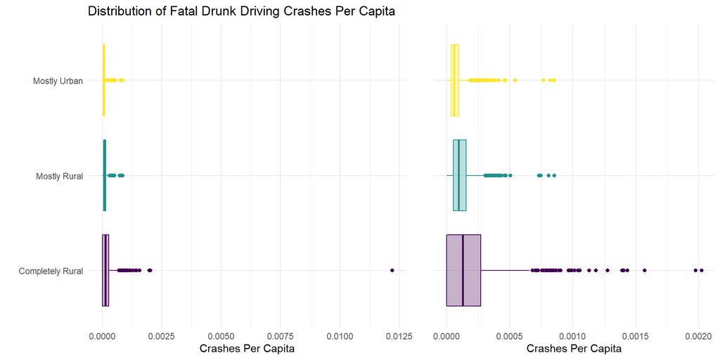

| County | State | Population | All Fatal Crashes | Fatal Drunk Driving Crashes | Per Capita Rate |
| --- | --- | --- | --- | --- | --- |
| Petroleum | MT | 494 | 1 | 1 | 0.0020243 |
| De Baca | NM | 2022 | 8 | 4 | 0.0019782 |
| McKenzie | ND | 6360 | 19 | 10 | 0.0015723 |
| Jackson | CO | 1394 | 2 | 2 | 0.0014347 |
| Mineral | CO | 712 | 3 | 1 | 0.0014045 |
| Treasure | MT | 718 | 1 | 1 | 0.0013928 |
| Esmeralda | NV | 783 | 5 | 1 | 0.0012771 |
| Hinsdale | CO | 843 | 1 | 1 | 0.0011862 |
| Sherman | OR | 1765 | 3 | 2 | 0.0011331 |
| Meagher | MT | 1891 | 2 | 2 | 0.0010576 |

In order to construct our models we used elastic net regression, a form of regularized linear regression. This means that we constructed our models in a way that both minimized mean-squared error and penalized the addition of new variables to the model in an effort to reduce the magnitude and variability of coefficients. By doing this, we sacrificed bias for a reduction in variability with the goal of achieving a balance between the two. There are three common methods of regularized linear regression: ridge, lasso, and elastic net. In ridge regression, the loss function – mean-squared error in our case – incorporates the squared coefficient values as a penalty expression which drives coefficients toward zero in an asymptotic manner such that all variables are included in the model, but only those that are significant have coefficients of any magnitude. In lasso regression, by contrast, the absolute value of the coefficients acts as a penalty in the loss function which forces the coefficients of insignificant variables to equal zero while those of significant variables are retained thereby reducing the complexity of the model. And finally, in elastic net regression, the linear combination of the ridge and lasso regression penalty expressions is used resulting in a model in which some coefficients have been driven asymptotically toward zero and others have been set to equal zero. Selection between these three regression methods in R is determined by the parameter alpha such that ridge regression is performed when alpha = 0, lasso regression is performed when alpha = 1, and elastic net regression is performed when alpha is between zero and one. Additionally, all three regression methods can be “tuned” via the parameter lamba which is multiplied by the penalty expression in a regression thereby determining the degree of impact that penalty has. If lambda were to be set to zero then no penalty would be applied at all.

For the purposes of our analysis, we used the cv.glmnet() function in R to construct ten different cross-validated models ranging from an alpha of 0 to an alpha of 1 in increments of 0.1. For each alpha we specified, this function used 10-fold cross validation to determine a corresponding lambda that would minimize mean-squared error. Once we had these ten models defined by their unique alpha and lambda values, we used mean-squared error and complexity to determine the best model. The best model we found using this method had an alpha of 0.3 and a lambda of 0.00010645939, however, its mean-squared error of 0.00000001662434 was only marginally lower than that of the lasso regression-like model (alpha = 1.0) which had a mean-squared error of 0.00000001672367. Thus, we chose to proceed with the later model based on its greater simplicity. This model had an alpha of 1.0 and a lambda of 0.00003846921; shown below are coefficients of the non-zero parameters in this model, a plot of the predicted per capita rates of fatal crashes involving drunk drivers, and a plot of the residuals from these predictions.

| Parameter | Coefficient |
| --- | --- |
| Intercept | 1.03e-04 |
| Rural Population Percentage * Average Speed Limit | 3.52e-09 |

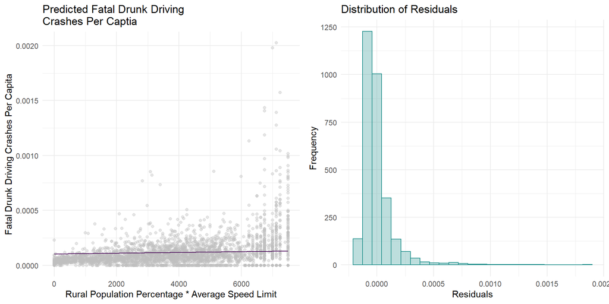

As shown above, the only variable determined to be a significant predictor of fatal drunk driving crashes per capita by our model was the multiplicative interaction between the percentage of the county’s population that lives in rural areas and the average maximum speed limit in the state. However, that being said, the plot of predictions shown above highlights the high level of variability in our data. In the plot, the purple line represents predictions from our model and the grey scatter plot represents actual observations thereby illustrating that, while the model we developed indicates a significant pattern in our data, its predictive capacity appears to be low. Furthermore, the plot of residuals shown above is noticeably right-skewed and centered below zero. This indicates that the model slightly overestimates a large portion of the data while simultaneously greatly underestimating a smaller segment.

## Question 1

Our first question was, “Can you predict if a drunk driver was involved in a crash?” We approached this question by deciding that the most logical predictors are the time of day, land use (rural or urban), and the collision type (Angle, Front-to-Front, Front-to-Rear, and Not in Collision With Motor Vehicle in Transport). We first started by thinking about what time would be most likely for a drunk driver to be involved in a crash. It would make sense for midnight to be a good time in urban areas, as people are likely to be in and out of bars at the time. We used this logic as a comparison point when analyzing the results of the data.

When predicting the presence of a drunk driver, we noticed that the results from the data seemed to follow our logic. It was interesting, though, to see that the results for rural areas were contradicting the results for urban areas. This could be due to a couple of different reasons. First off, drinking culture, in general, is different in rural areas. Studies show that the lifetime prevalence of alcohol consumption in rural areas is significantly higher than in urban areas. Alcohol abuse, the specific topic, in this case, leads to most cases of drunk driving, and there are many different reasons why this is the case. A big reason for these high drunk driving mortality rates is that drugs are not as readily available in rural areas as they are in large metropolitan areas. This could cause addicts to rely on alcohol, which can lead to the higher percentage that rural areas share of alcohol abuse. Poverty, unemployment, and isolation could also be the cause of these high numbers. It would be much more difficult for a substance abuser to seek medical attention when they are experiencing those factors. This can cause addicts and abusers to worsen their alcohol use indefinitely over time, as there may be no figure that can intervene.

The model above may reflect the drinking culture in rural areas, as the probability (log-odds) of a drunk driver being involved in the crash increases as the day goes on. Though this is counterintuitive if rural drunk driving crashes are approached with the same lense that analyzes urban areas, it is important to understand the difference between the drinking culture in both types of areas and its effects on alcohol abuse cases. When testing the accuracy of the model, we were satisfied with how well drunk drivers were predicted to be involved in a crash. The model was 73% accurate, which shows that the graphs above quite accurate for the predictors that are used. It is quite tough to predict if a drunk driver was involved, as the danger that they present is the randomness at which they could kill somebody on the road. There can be an infinite amount of predictors when looking at this topic, but the ones that made the most logical sense have been proven to be quite accurate from our model.

[interactive chart not shown]

```
## [1] 0.7264653
```

[figure not shown]

# Conclusion

Motor vehicle accidents are one of the leading causes of death in the United States. According to CDC data, there were over 40,231 motor vehicle accidents in 2017, up from 35,092 in 2015. Through identifying trends and better understanding the possible causes of fatal accidents, policies can be implemented and information can be disseminated to help keep people safer on the roads. Of the major factors that cause motor vehicle accident deaths (not wearing seatbelt, impaired driving, distracted driving, reckless driving), drunk driving comprises a large portion of fatal accidents. If measures are taken to reduce drunk driving, many lives can be saved each year. State governments can use our findings to identify times of the day in both urban and rural areas where it would be most effective to place DUI checkpoints to keep drunk drivers off the road. They can also use the findings about the manner of collision and set up checkpoints where these types of crashes most happen, like near intersections or busy roadways.

The findings in question 1 can be applied more generally to catching drunk drivers throughout the whole country by informing their prevention approach with what factors actually contribute to drunk driving. The findings in question 2 are location specific and can be used by respective state and local governments to inform new initiatives in their communities to combat drunk driving. Knowing that the interaction between the percentage of the county’s population that lives in rural areas and the average maximum speed limit in the state can predict the per capita rate of fatal drunk driving accidents, governments may find that they should lower the speed limits if a large portion of their population live in rural areas.

How to stay safe while driving a car is a well told story: wear a seatbelt, do not drive drunk, do not use your phone, pay attention to the road. However, there are always new findings to be made in car accident data, especially datasets of this magnitude. We were able to examine the variables included in the dataset at each accident (time, location, land type, manner of collision - just to name a few) to draw inferences and make predictions about drunk driving. If several other variables were included, it would have made for a more robust analysis of DD. Knowing personal data about the driver like age, gender, type of car, whether they were wearing a seatbelt, and how many people were in the car would be interesting to include in the model to see which factors put a driver most at risk of getting into a drunk driving accident. Instead of looking at which factors about the crash make it most likely to have involved drinking, incorporating factors about the driver into the model may allow for more insights to be derived that help with prevention. This information could be used by insurance companies to raise rates for those at highest risk, which is unfortunate, but is how insurance companies operate. It also would have been useful to examine all motor vehicle accidents so severity of accidents could be predicted based on the many factors present. In this dataset, the number of fatalities could have been used as a proxy for crash severity, but the number of people in the vehicle is largely due to chance and does not truly indicate how severe the crash was (ie. how much damage the car suffered, whether the driver and/or passenger were killed). It would have been useful to have access to data about how many crashes were related to distracted driving. Distracted driving may be the more relevant concern for our generation than drunk driving. According to the National Highway Traffic Safety Administration, drunk driving fatality rates are down 13% in the past 10 years while the proliferation of smartphones has caused distracted driving accidents to increase every year. While the country’s young people definitely take a safer approach to drunk driving than past generations have, and it still remains a problem, but possibly a more relevant problem for today’s drivers to search for solutions in the data is distracted driving. Even still, the advent of self-driving cars will certainly make our roads safer, but until this new technology becomes ubiquitous, certain changes can be put into place to protect people that share the road every day.